# Practical LM Project - Week 4

Sanjay P Joshi

October 6, 2020

## Importing data

Let us first import the data

```r
trainData <- read.csv(url("https://d396qusza40orc.cloudfront.net/predmachlearn/pml-training.csv"))
testData <- read.csv(url("https://d396qusza40orc.cloudfront.net/predmachlearn/pml-testing.csv"))
```

## Understanding the data

To understand the data, let us examine the training data set with `str` command

```r
str(trainData)
```

```
## 'data.frame':    19622 obs. of  160 variables:
##  $ X                       : int  1 2 3 4 5 6 7 8 9 10 ...
##  $ user_name               : chr  "carlitos" "carlitos" "carlitos" "carlitos" ...
##  $ raw_timestamp_part_1    : int  1323084231 1323084231 1323084231 1323084232 1323084232 1323084232 1323084232 1323084232 1323084232 1323084232 ...
##  $ raw_timestamp_part_2    : int  788290 808298 820366 120339 196328 304277 368296 440390 484323 484434 ...
##  $ cvtd_timestamp          : chr  "05/12/2011 11:23" "05/12/2011 11:23" "05/12/2011 11:23" "05/12/2011 11:23" ...
##  $ new_window              : chr  "no" "no" "no" "no" ...
##  $ num_window              : int  11 11 11 12 12 12 12 12 12 12 ...
##  $ roll_belt               : num  1.41 1.41 1.42 1.48 1.48 1.45 1.42 1.42 1.43 1.45 ...
##  $ pitch_belt              : num  8.07 8.07 8.07 8.05 8.07 8.06 8.09 8.13 8.16 8.17 ...
##  $ yaw_belt                : num  -94.4 -94.4 -94.4 -94.4 -94.4 -94.4 -94.4 -94.4 -94.4 -94.4 ...
##  $ total_accel_belt        : int  3 3 3 3 3 3 3 3 3 3 ...
##  $ kurtosis_roll_belt      : chr  "" "" "" "" ...
##  $ kurtosis_picth_belt     : chr  "" "" "" "" ...
##  $ kurtosis_yaw_belt       : chr  "" "" "" "" ...
```

[output cut: 86 more lines]

Looking through this, we identify the following...

1. This is a large data set with 160 columns
2. An unspecified number of columns seem to have large `NA` values
3. An unspecified number of columns seem to have large number of blank values.

Let us understand this further...

- First the NAs

```r
naCols <- colSums(is.na(trainData))
table(naCols)
```

```
## naCols
##     0 19216
##    93    67
```

- Next the blanks

```r
blankCols<-apply(X = trainData, MARGIN = 2, FUN = function(x){sum(x[!is.na(x)]=="")})
#Note this...x[!is.na(x)] is used as if there are NA values, the columns will return NA
table(blankCols)
```

```
## blankCols
##     0 19216
##   127    33
```

## Cleaning the data

1. We thus see 100 columns having a large number (19216) of values being either blank or `NA`s. It make no sense to keep them. Thus we shall remove these columns from our analysis.

```r
removeCols <- c(names(blankCols[blankCols==19216]),names(naCols[naCols==19216]))
cTrainData <- trainData[,!(names(trainData) %in% removeCols)]
cTestData<- testData[,!(names(trainData) %in% removeCols)]
```

2. Let us clear near zero variance columns

```r
nzv <- nearZeroVar(cTrainData)
cTrainData <- cTrainData[, -nzv]
cTestData <- cTestData[,-nzv]
```

3. We can also ignore the first 6 columns...

```r
cTrainData <- cTrainData[,-c(1:6)]
cTestData <- cTestData[,-c(1:6)]
```

Having done all the cleanup's let us check our data now.

```r
dim(cTrainData)
```

```
## [1] 19622    53
```

```r
dim(cTestData)
```

```
## [1] 20 53
```

We end up with 53 columns.

## Data preparation for applying algorithms

To implement prediction algorithms, let us divide our training data set further, and apply predictions algorithm to do a check.

```r
set.seed(5432)
div1 <- createDataPartition(cTrainData$classe, p=0.75, list=FALSE)
trainDataDiv1 <- cTrainData[div1,]
trainDataDiv2 <- cTrainData[-div1,]
dim(trainDataDiv1)
```

```
## [1] 14718    53
```

## Cross validation

Let us also use cross validation uptil 5 levels.

```r
trnCtrl <- trainControl(method="cv", number=5)
# to be used as a control in the upcoming training algorithms.
```

## Applying training models.

We shall apply the following models, and check for the one with highest efficiency, in our test set.

- Classification trees
- GBM
- Random Forest

### Classification tree

Let us apply for the classification tree alogorithm.

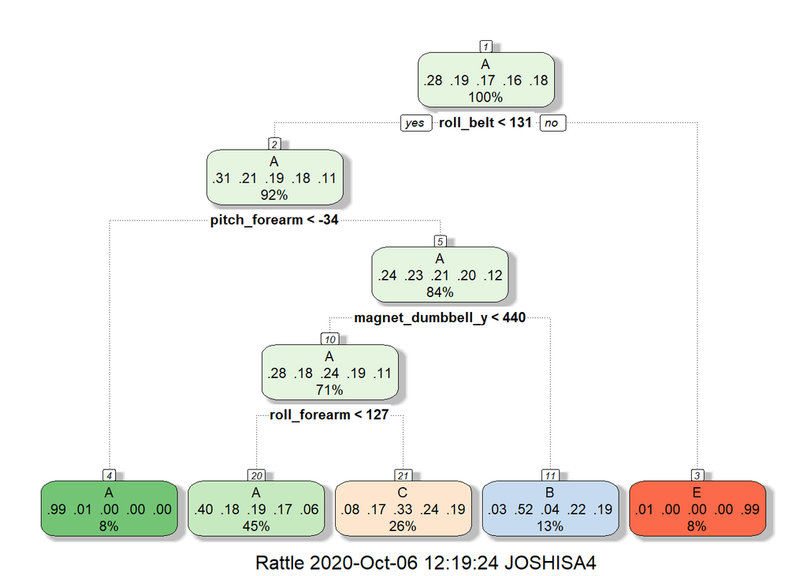

```r
rPartMod <- train(classe~., data=trainDataDiv1, method="rpart", trControl=trnCtrl)
fancyRpartPlot(rPartMod$finalModel)
```

Let us now predict or our sample test data drawn out of training data and check the accuracy of this model...

```r
predRPart <- predict(rPartMod,newdata=trainDataDiv2)
confMat <-confusionMatrix(table(predRPart,trainDataDiv2$classe))
confMat$overall["Accuracy"]
```

```
##  Accuracy
## 0.4916395
```

We see the accuracy is **49.16%** for classification trees

### Gradient Boosting Method(GBM)

Let us now train with gradient boosting method.

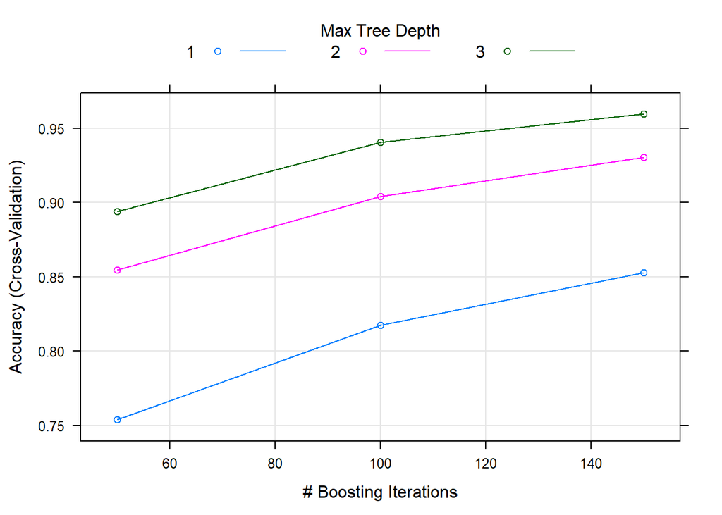

```r
modGBM <- train(classe~., data=trainDataDiv1, method="gbm", trControl=trnCtrl, verbose=FALSE)
plot(modGBM)
```

Like we did above, we will apply this to test data obtained from dividing the training data and check the accuracy.

```r
predGBMTrain <- predict(modGBM,newdata=trainDataDiv2)
confMatGBM <- confusionMatrix(table(predGBMTrain,trainDataDiv2$classe))
confMatGBM$overall["Accuracy"]
```

```
##  Accuracy
## 0.9653344
```

### Random Forest

Let us now train with random forests method.

```r
modRF <- train(classe~., data=trainDataDiv1, method="rf", trControl=trnCtrl, verbose=FALSE)
```

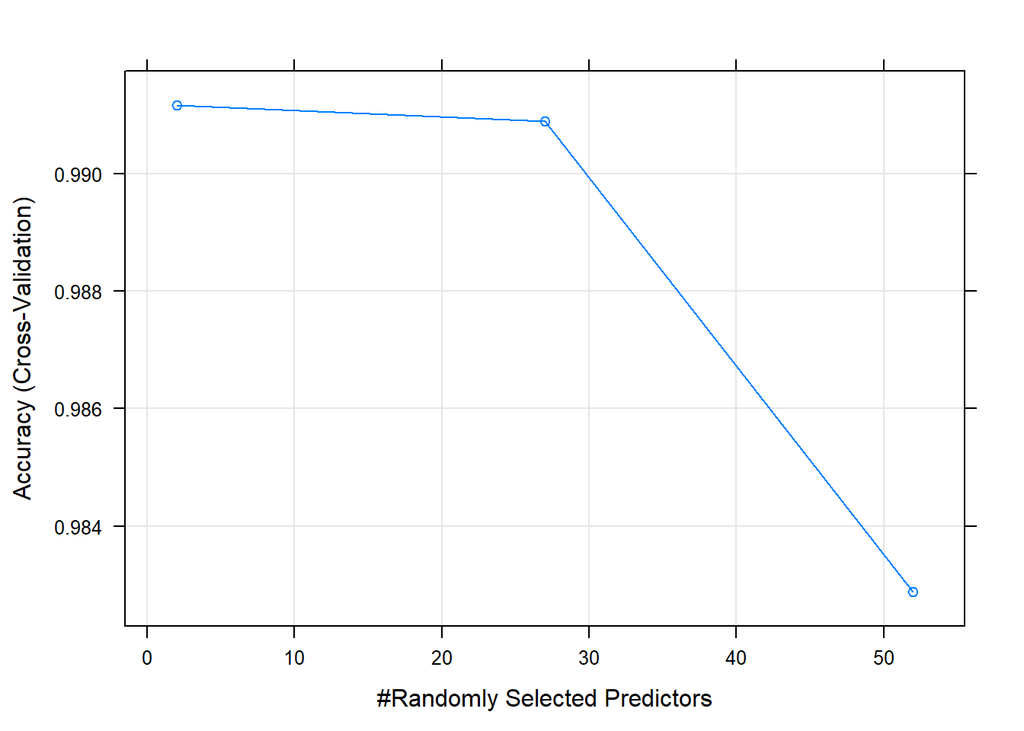

```r
plot(modRF)
```

We will apply this to test data obtained from dividing the training data and check the accuracy

```r
predRFTrain <- predict(modRF,newdata=trainDataDiv2)
confMatRF <- confusionMatrix(table(predRFTrain,trainDataDiv2$classe))
confMatRF$overall["Accuracy"]
```

```
## Accuracy
## 0.992863
```

## Conclusion

We can see from the above analysis, that the random forest seems to work the best. The expected accuracy is **99.28%**. Thus the **expected out of sample error will be 0.72%**

Let us predict on our test set using this model

```r
testPredVal <- predict(modRF,newdata=cTestData)
testPredVal
```

```
##  [1] B A B A A E D B A A B C B A E E A B B B
## Levels: A B C D E
```